# Seurat HBCA Workshop

## Step 6. Linear dimensionality reduction using principal component analysis (PCA)

In principle one can start to look at cell heterogeneity after identifying highly variable genes and scaling the data. However, applying a linear dimension reduction before doing any further analysis is strongly recommended and sometimes even seen as compulsory. The benefit of doing such a dimension reduction includes but is not limited to: 1. The data becomes much more compact so that computation becomes much faster. 2. As scRNA-seq data is intrinsically sparse, summarizing measurements of related features greatly enhances the signal robustness.

```r
#PCA
hbca <- RunPCA(hbca, features = VariableFeatures(object = hbca))

# Examine and visualize PCA results a few different ways
print(hbca[["pca"]], dims = 1:5, nfeatures = 5)
```

```
## PC_ 1
## Positive:  KRT18, KRT8, CD24, AZGP1, EPCAM
## Negative:  VIM, DCN, LUM, COL1A2, LGALS1
## PC_ 2
## Positive:  CD93, ADGRL4, VWF, PECAM1, FLT1
## Negative:  DCN, LUM, COL1A2, COL1A1, FBLN1
## PC_ 3
## Positive:  PTPRC, CXCR4, RGS1, IL7R, SAMSN1
## Negative:  AGR2, MAST4, TMC5, DNAJC12, RASEF
## PC_ 4
## Positive:  SFRP1, CRYAB, MFGE8, CCL28, NTRK2
## Negative:  SYTL2, RGS1, SRGN, GPR183, CXCR4
## PC_ 5
## Positive:  EMP1, SOD2, CCL28, PIGR, ALDH1A3
## Negative:  ACTA2, TAGLN, MYLK, C2orf40, TPM2
```

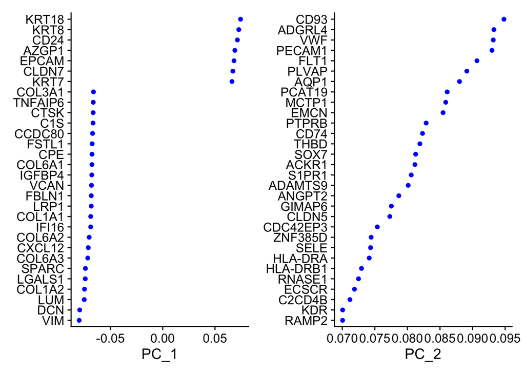

```r
VizDimLoadings(hbca, dims = 1:2, reduction = "pca")
```

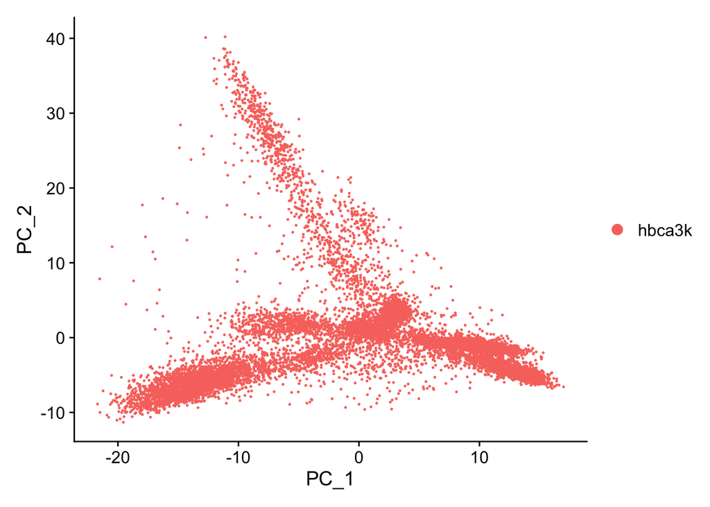

```r
DimPlot(hbca, reduction = "pca")
```

The number of principal components (PCs) that one can calculate for a data set is equal to the number of highly variable genes or the number of cells, whichever value is smaller. However, most of these PCs are not informative and only represent random noise. Only the top PCs are informative and represent differences among cell populations. Therefore, instead of calculating all possible PCs, Seurat uses truncated PCA to only calculate the first PCs, by default the top 50 PCs. One can change that by setting the `npcs` parameter.

Even then, one doesn’t necessarily use all the calculated PCs. Determinting how many top PCs to use is an art. There is no golden standard, and everyone has his/her own understanding. The so-called elbow plot method can help with the decision. It consists of plotting the explained variation as a function of each PC, and picking the elbow of the curve as the number of PCs to use.

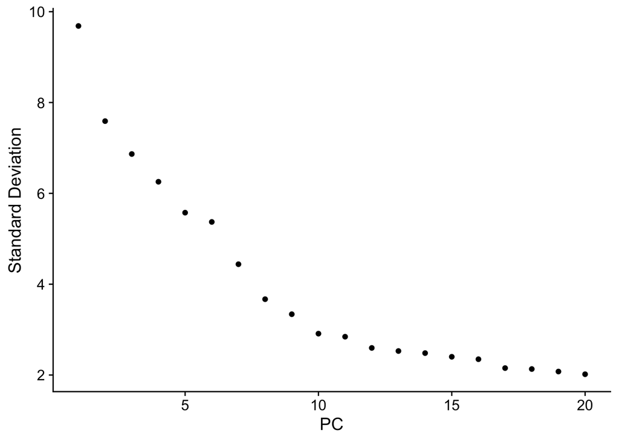

```r
#elbow plot
ElbowPlot(hbca)
```

Apart from making an unbiased decision, one can also check which genes are mostly contributing to each of the top PCs . This can be informative if one knows the genes and the biology of the analyzed sample. It provides the opportunity to understand the biological implication of each of the top PCs, so that one can pick those representing useful information.

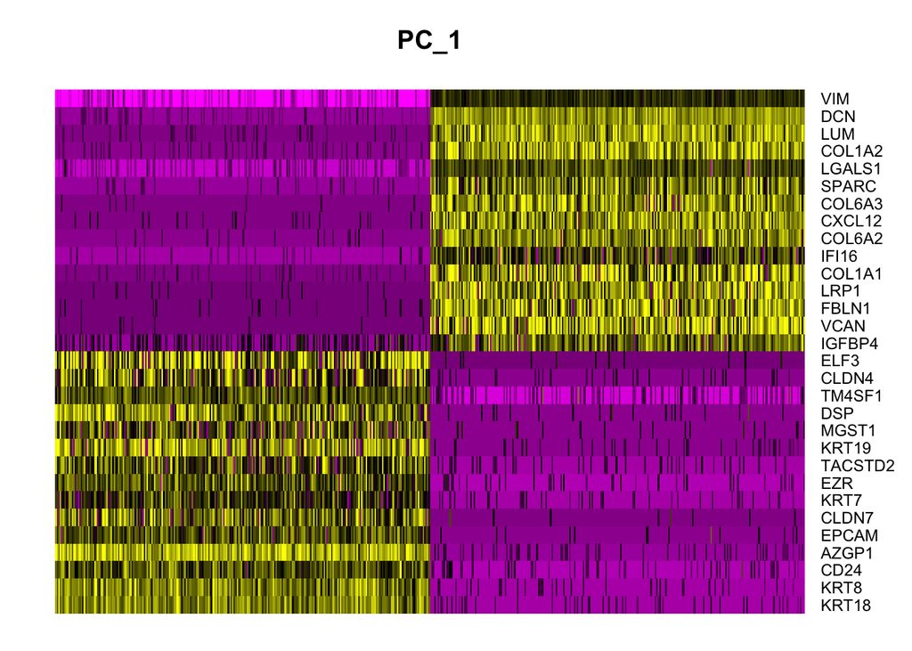

```r
#PCA heatmaps
DimHeatmap(hbca, dims = 1, cells = 500, balanced = TRUE)
```

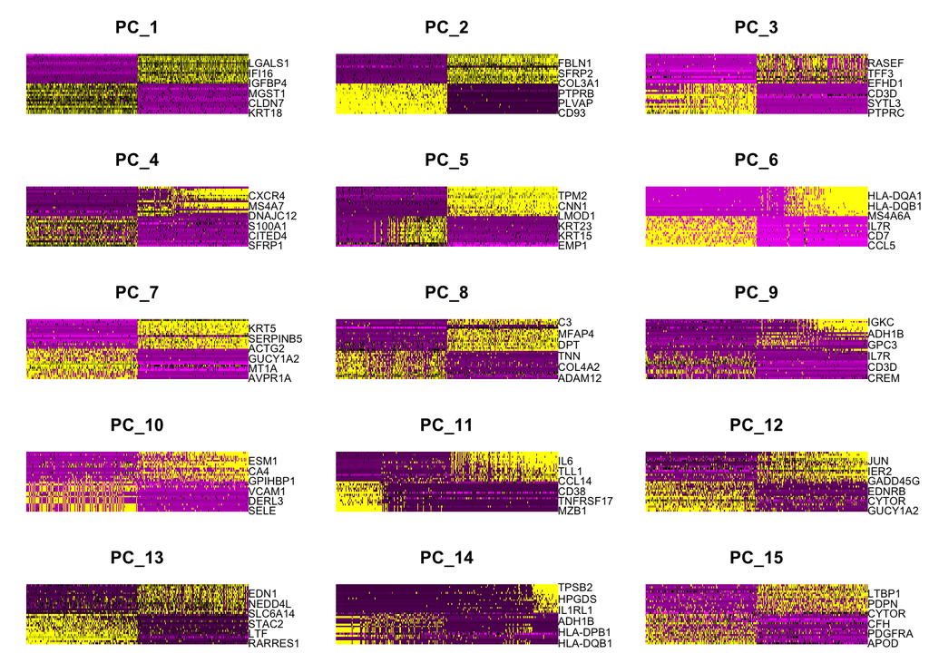

```r
DimHeatmap(hbca, dims = 1:15, cells = 500, balanced = TRUE)
```